# Assignment 3

Srecko Curkovic

12/7/2020

The purpose of this assignment is to run a regression analysis to explore an urban topic.

We start with the initial knitting set-up. We want to show all code on the web report and we want to run it, but we do not want to show warnings and messages. We also want to show the final plots as outputs.

```r
knitr :: opts_chunk$set(include = T, echo = T, warning = F, message = F, eval = T)
```

We then load all the libraries necessary for this assignment (including census and plotting libraries). There are also two lines of code related to the tigris cache that help resolve an issue that kept appearing when running the code.

```r
options(tigris_use_cache = F)
options(tigris_use_cache = T)

library(tidyverse)
library(censusapi)
library(corrplot)
library(tidycensus)
```

This assignment makes use of the American Communities Survey data. Therefore we need to set up a personal API key to access the Census API. We also conveniently read the contents of the 5-year census data dictionary using listCensusMetadata().

```r
Sys.setenv(CENSUS_KEY="e8143dd114a4e506d99d31b8a69753783c09bd0a")

acs_vars_2018_5yr <-
  listCensusMetadata(
    name = "2018/acs/acs5",
    type = "variables"
  )
```

The following workflow uses getCensus() to prepare the data sets for the analysis. The ACS data is analyzed on the level of census tracts and is referring to 2018. We are interested in the data for California; more specifically, the nine Bay Area counties. The analysis is done on the level of households.

The next step is to choose the outcome variables to be used for the regression. There is one dependent variable and two independent variables. All three are continuous and all three represent percentages.

The dependent variable is percentage of public transportation (excluding taxicab) as means of transportation to work, denoted as perc_pt. It was found by dividing public transportation values by the total values for means of transportation to work, as shown below using the ACS variables.

The first independent variable is percentage of white households. It was found in the same way as in the textbook and is denoted as perc_white here.

The second independent variable is percentage of househoolds with income less than $30k (in 2018 inflation-adjusted dollars). It was found using the five income buckets as shown below annd is denoted as perc_below30k.

The motivation for this choice of outcome and variables comes from reading about the Pew Research Center survey called “Who relies on public transit in the U.S.” It can be found at: https://www.pewresearch.org/fact-tank/2016/04/07/who-relies-on-public-transit-in-the-u-s/. It found that “who is taking public transit varies substantially by region, nativity, and race and ethnicity.” Among the three racial/ethnic groups (White, Black, Hispanic), white people use public transportation the least. When it comes to income, those with the income of less than $30k were using public transportation the most.

```r
bay_multiple_tract <-
  getCensus(
    name = "acs/acs5",
    vintage = 2018,
    region = "tract:*",
    regionin = "state:06+county:001,013,041,055,075,081,085,095,097",
    vars = c(
      "B19001A_001E",
      "B19001_001E",

      "B08301_001E",
      "B08301_010E",

      "B19001_001E",
      "B19001_002E",
      "B19001_003E",
      "B19001_004E",
      "B19001_005E",
      "B19001_006E"
    )
  ) %>%
  transmute(
    tract = paste0(state, county, tract),
    perc_white = B19001A_001E / B19001_001E,
    perc_pt = B08301_010E / B08301_001E,
    perc_below30k = (B19001_002E + B19001_003E + B19001_004E + B19001_005E + B19001_006E) / B19001_001E
  ) %>%
  filter(
    !is.na(perc_white),
    !is.na(perc_pt),
    !is.na(perc_below30k)
  )
```

We can first briefly look at the two simple regression plots and models.

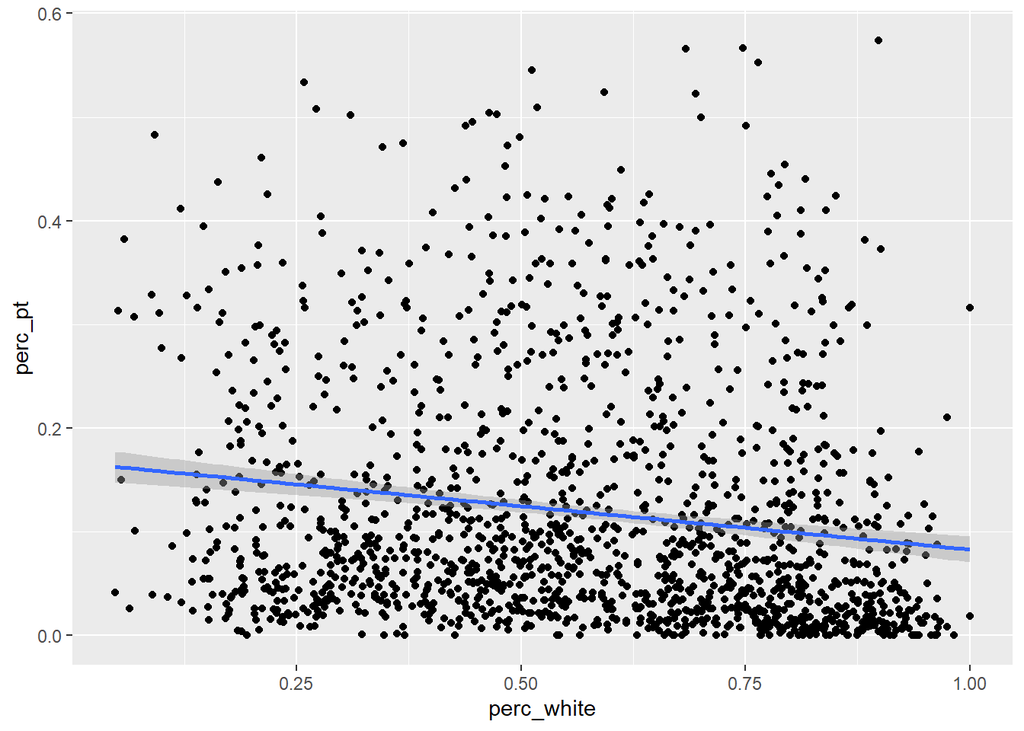

```r
ggplot(
  data = bay_multiple_tract,
  aes(
      x = perc_white,
      y = perc_pt
    )
) +
  geom_point() +
  geom_smooth(method = "lm")
```

```r
model1 <- lm(perc_pt ~ perc_white, bay_multiple_tract)
summary(model1)
```

```
##
## Call:
## lm(formula = perc_pt ~ perc_white, data = bay_multiple_tract)
##
## Residuals:
##      Min       1Q   Median       3Q      Max
## -0.15051 -0.08350 -0.04353  0.04946  0.48219
##
## Coefficients:
##              Estimate Std. Error t value Pr(>|t|)
## (Intercept)  0.166813   0.008065  20.684  < 2e-16 ***
## perc_white  -0.083783   0.013097  -6.397 2.09e-10 ***
## ---
## Signif. codes:  0 '***' 0.001 '**' 0.01 '*' 0.05 '.' 0.1 ' ' 1
##
## Residual standard error: 0.1165 on 1575 degrees of freedom
## Multiple R-squared:  0.02532,    Adjusted R-squared:  0.0247
## F-statistic: 40.92 on 1 and 1575 DF,  p-value: 2.085e-10
```

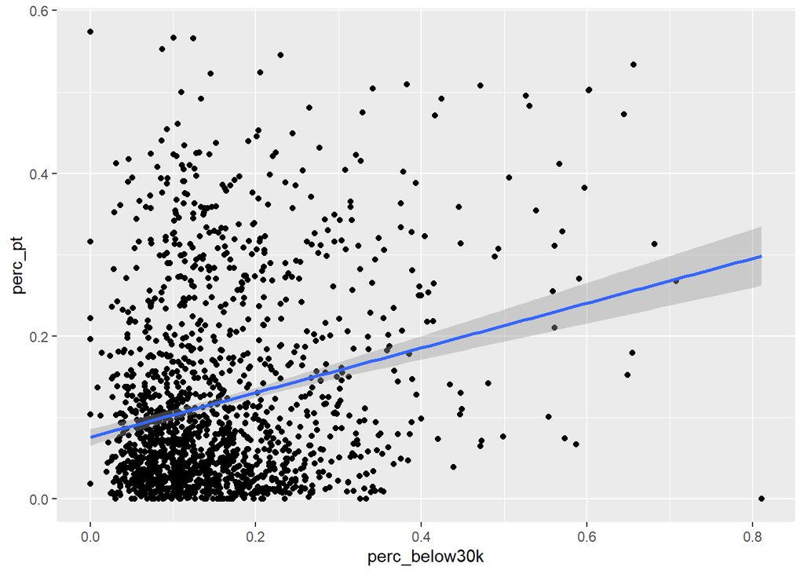

```r
ggplot(
  data = bay_multiple_tract,
  aes(
      x = perc_below30k,
      y = perc_pt
    )
) +
  geom_point() +
  geom_smooth(method = "lm")
```

```r
model2 <- lm(perc_pt ~ perc_below30k, bay_multiple_tract)
summary(model2)
```

```
##
## Call:
## lm(formula = perc_pt ~ perc_below30k, data = bay_multiple_tract)
##
## Residuals:
##      Min       1Q   Median       3Q      Max
## -0.29850 -0.08068 -0.03744  0.04906  0.49781
##
## Coefficients:
##               Estimate Std. Error t value Pr(>|t|)
## (Intercept)   0.075958   0.005227  14.531   <2e-16 ***
## perc_below30k 0.274471   0.027964   9.815   <2e-16 ***
## ---
## Signif. codes:  0 '***' 0.001 '**' 0.01 '*' 0.05 '.' 0.1 ' ' 1
##
## Residual standard error: 0.1145 on 1575 degrees of freedom
## Multiple R-squared:  0.05764,    Adjusted R-squared:  0.05704
## F-statistic: 96.33 on 1 and 1575 DF,  p-value: < 2.2e-16
```

The first plot shows that in tracts with a higher percentage of white people, public transportation is generally used less, and vice versa. This agrees with the survey results. However, the data does not show a clear linear trend.

The model shows a negative coefficient which agrees with what was said above. The p-value is low and there are *** so the independent variable is statistically significant. Around 2.5% of variation in perc_put is explained by perc_white only, which is a very low R-squared value. Race alone is not enough as an indicator of the use of public transportation.

The second plot shows that in tracts with higher percentage of households with income less than $30k, public transportation is used more. This also agrees with the survey results. The trend is slightly more linear, but still not completely linear.

The model shows a positive coefficient which agrees with what was said above. The p-value is low and there are *** so the independent variable is statistically significant. Close to 6% of variation in perc_pt is explained by perc_below30k only, which is a higher R-squared value than before. Even though income alone is not enough as an indicator of the use of public transportation, it might be better than race.

Now we run a multiple regression model with the three variables as described above.

```r
model3 <- lm(perc_pt ~ perc_white + perc_below30k, bay_multiple_tract)

summary(model3)
```

```
##
## Call:
## lm(formula = perc_pt ~ perc_white + perc_below30k, data = bay_multiple_tract)
##
## Residuals:
##      Min       1Q   Median       3Q      Max
## -0.27800 -0.08136 -0.03876  0.04610  0.50801
##
## Coefficients:
##               Estimate Std. Error t value Pr(>|t|)
## (Intercept)    0.10855    0.01064  10.198  < 2e-16 ***
## perc_white    -0.04765    0.01357  -3.511 0.000459 ***
## perc_below30k  0.24075    0.02947   8.169 6.34e-16 ***
## ---
## Signif. codes:  0 '***' 0.001 '**' 0.01 '*' 0.05 '.' 0.1 ' ' 1
##
## Residual standard error: 0.1141 on 1574 degrees of freedom
## Multiple R-squared:  0.06496,    Adjusted R-squared:  0.06377
## F-statistic: 54.68 on 2 and 1574 DF,  p-value: < 2.2e-16
```

Both independent variables have p-values much lower than 0.05 so both of them are statistically significant (we can reject the null hypothesis), as indicated by ***.

The coefficient of perc_white is negative which means that increase in perc_white is related to decrease in perc_pt, which agrees with the simple regression plot and the survey. The coefficient of perc_below30k is positive which means that increase in perc_below30k is related to increase in perc_pt which agrees with the simple regression analysis and the survey.

The R-squared value shows us that around 6% of variation in the dependent variable is explained by this model. This value is relatively low which indicates that these two independent variables are not enough to explain the use of public transportation. It is interesting to see that combining the two variables increased the R-squared value only a little bit, so the combination of race and income might not necessarily be much better in explaining public transportation use than income alone.

We can also create the correlation plot to see the interactions of the three variables without necessarily thinking of them as dependent and independent.

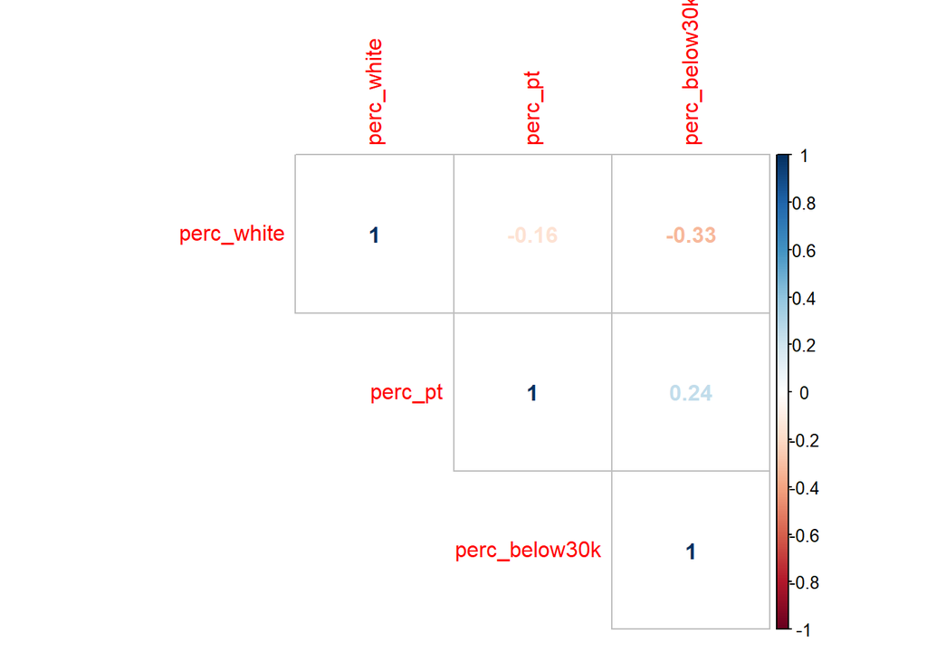

```r
correlationplot <- bay_multiple_tract %>%
  select(
    perc_white,
    perc_pt,
    perc_below30k
  ) %>%
  cor()

corrplot(
  correlationplot,
  method = "number",
  type = "upper"
)
```

The negative value of -0.16 and the positive value of 0.24 agree with the discussion above. A new piece of information is the negative value of -0.33 which means that higher perc_white values are associated with a lower perc_below30k values, which is not too surprising.

The regression analysis above indicates that race and income do not provide a full picture when it comes to understanding who uses public transportation the most and why. Therefore, no causal claims can be made. However, there might be possible explanations for some of the trends seen. The Pew Research Center survey suggests:

“One possible reason that blacks, Hispanics and immigrants might be bigger users of public transit is because they are more likely than Americans overall to live in large metropolitan areas, where there tend to be more public transit options. They are also less likely to have access to an automobile than other groups and are more likely to use public transit for commuting to work. Blacks and Hispanics also tend to live farther away from their jobs, which could make walking or biking to work less common.”

They are also careful to not claim any causal relationships while trying to suggest possible explanations.

Since the analysis above used census tract data, it would be useful to do a similar analyis using PUMS household data. Below is my attempt to run this analysis. However, I encountered some issues with the code that I was not able to resolve, but I am still attaching the code here for the sake of completeness.

```r
census_api_key("e8143dd114a4e506d99d31b8a69753783c09bd0a")

pums_vars_2018 <-
  pums_variables %>%
  filter(year == 2018, survey == "acs5")
```

```r
ca_pums <- get_pums(
  variables = c(
    "PUMA",
    "NP",
    "RAC1P",
    "HINCP",
    "JWTR"
  ),
  state = "CA",
  year = 2018,
  survey = "acs5",
  recode = T
)

ca_pumas <-
  pumas("CA", cb = T, progress_bar = F)

bay_county_names <-
  c(
    "Alameda",
    "Contra Costa",
    "Marin",
    "Napa",
    "San Francisco",
    "San Mateo",
    "Santa Clara",
    "Solano",
    "Sonoma"
  )

bay_counties <-
  counties("CA", cb = T, progress_bar = F) %>%
  filter(NAME %in% bay_county_names)

bay_pumas <-
  ca_pumas %>%
  st_centroid() %>%
  .[bay_counties, ] %>%
  st_set_geometry(NULL) %>%
  left_join(ca_pumas %>% select(GEOID10)) %>%
  st_as_sf()

bay_pums <-
  ca_pums %>%
  filter(PUMA %in% bay_pumas$PUMACE10)
```

```r
bay_pums_regression <-
  bay_pums %>%
  filter(SPORDER == 1) %>%
  mutate(
    white = ifelse(
      RAC1P_label == "White alone",
      1,
      0
    )
  )
```

```r
model1_pums <- lm(JWTR ~ white, bay_pums_regression, weights = WGTP)
model2_pums <- lm(JWTR ~ HINCP, bay_pums_regression, weights = WGTP)
model3_pums <- lm(JWTR ~ white + HINCP, bay_pums_regression, weights = WGTP)

summary(model1_pums)
summary(model2_pums)
summary(model3_pums)
```

Let us now do another regression analysis similar to the first one. The only change will be in the outcome (dependent variable). Now we are considering the percentage of public transportation by bus or trolley bus only, denoted as perc_pt2.

```r
bay_multiple_tract_2 <-
  getCensus(
    name = "acs/acs5",
    vintage = 2018,
    region = "tract:*",
    regionin = "state:06+county:001,013,041,055,075,081,085,095,097",
    vars = c(
      "B19001A_001E",
      "B19001_001E",

      "B08301_001E",
      "B08301_011E",

      "B19001_001E",
      "B19001_002E",
      "B19001_003E",
      "B19001_004E",
      "B19001_005E",
      "B19001_006E"
    )
  ) %>%
  transmute(
    tract = paste0(state, county, tract),
    perc_white = B19001A_001E / B19001_001E,
    perc_pt2 = B08301_011E / B08301_001E,
    perc_below30k = (B19001_002E + B19001_003E + B19001_004E + B19001_005E + B19001_006E) / B19001_001E
  ) %>%
  filter(
    !is.na(perc_white),
    !is.na(perc_pt2),
    !is.na(perc_below30k)
  )
```

```r
model4 <- lm(perc_pt2 ~ perc_white + perc_below30k, bay_multiple_tract_2)

summary(model4)
```

```
##
## Call:
## lm(formula = perc_pt2 ~ perc_white + perc_below30k, data = bay_multiple_tract_2)
##
## Residuals:
##      Min       1Q   Median       3Q      Max
## -0.18787 -0.03834 -0.02380  0.00418  0.39747
##
## Coefficients:
##                Estimate Std. Error t value Pr(>|t|)
## (Intercept)    0.040201   0.007028   5.720 1.27e-08 ***
## perc_white    -0.030997   0.008961  -3.459 0.000557 ***
## perc_below30k  0.202792   0.019459  10.422  < 2e-16 ***
## ---
## Signif. codes:  0 '***' 0.001 '**' 0.01 '*' 0.05 '.' 0.1 ' ' 1
##
## Residual standard error: 0.07533 on 1574 degrees of freedom
## Multiple R-squared:  0.09289,    Adjusted R-squared:  0.09174
## F-statistic: 80.59 on 2 and 1574 DF,  p-value: < 2.2e-16
```